# HW2Telemetery

Elijah Hall

May 31, 2018

## Telemetery

```r
library(rmarkdown)
library(tidyverse)
library(lubridate)
library(data.table)

library(TTR)
library(zoo)
library(cumstats)
library(corrplot)

#visual theme
mytheme <- theme_bw()+
  theme(panel.border = element_blank(),
        axis.line = element_line(color = 'black'),
        plot.background = element_blank(),
        panel.grid.major = element_blank(),
        panel.grid.minor = element_blank())
```

## Case 2: Telemetry Data

The data if from a Java application (Weblogic based application) and was collected from JMX with multiple hosts and multiple processes. The raw data consists of 27,875 Files, 22.9 GB, 2 Years of data from 2014 to 2015. The system output pre-processed aggregate features and evaluation metrics that consist of 200 files, 9.3 GB. The data to be analyzed is this smaller data set of aggregated reporting features. A key note is that “-1” values will indicate missing values.

### Reading in and merging the data

```r
data_path <- "C:/Users/usmc_/Documents/APAN 5420 Anomaly Detection/Anomaly Detection R/FEATURES-2014-2015"   # path to the data
files <- dir(data_path, pattern = "*.csv") # get file names
# there are some empty files so I removed them

length(files)
```

```
## [1] 200
```

```r
# 7163 unique stocks from combination of exhanges
# create a data frame holding the file names, read files into a new data column
```

#### Evaluating fastest option to read in files

With such large files it is hard to tell which is the best way to read them in. I want to test three different ways. The first is read_csv() which has been a fast a usefull function in the past but I have noticed with large files it can still be slow. The second is fread() which has been faster in the past at reading than read_csv. The third and final is the read function created and provided to teh class. I will read in the first file, size = 60MB

```r
speed<- data.frame(method = c("read_csv","fread","loadTelemetryFiles"), time_seconds = c(0,0,0) )

start<-proc.time()
test <- read_csv(paste0(data_path,"/",files[1]))
speed$time_seconds[1] <-(proc.time()-start)[3]

start<-proc.time()
test <- fread(paste0(data_path,"/",files[1]))
speed$time_seconds[2] <- (proc.time()-start)[3]

start<-proc.time()
test <- loadTelemetryFiles(paste0(data_path,"/",files[1]))
speed$time_seconds[3] <- (proc.time()-start)[3]
```

```r
#which method is the fastest
paste0("The winner is ", speed[which(speed[,2] == min(speed[,2])),1], "()")
```

```
## [1] "The winner is fread()"
```

```r
speed
```

```
##                method time_seconds
## 1:           read_csv       339.69
## 2:              fread         1.41
## 3: loadTelemetryFiles        15.36
```

We can see the the obvious winner is fread. Surprisingly read_csv is much slower than I anticipated. Even teh function provided to the class is slower by about a factor of 10.

#### Read in the sample files

Using the best method I will read inthe first 5 files. There is an alternative way to read the files in and retain the file information. This is helpful when debugging. I will use option 2 during my EDA.

```r
#option 1
all <- map(filename, ~ fread(file.path(data_path, .)))
```

```r
#option 2 to keep file info to help with debugging
start<-proc.time()
all <- data_frame(filename = files[1:5]) %>%
  mutate(file_contents = map(filename,
            ~ fread(file.path(data_path, .))))

all <- unnest(all)

#remove file extension
all$filename <- str_split_fixed(all$filename, fixed("."), n = 2)[,1]

total_read_time<-(proc.time()-start)[3]
# takes about 4.5 seconds
total_read_time
```

```
## elapsed
##    3.01
```

[output not shown]

```r
head(names(all),10)
```

```
##  [1] "filename"
##  [2] "host"
##  [3] "process"
##  [4] "timestamp"
##  [5] "isAnomaly"
##  [6] "Prepared statement cache hit rate : ((MXBean(com.bea:Name=source06,Type=JDBCDataSourceRuntime).PrepStmtCacheHitCount / MXBean(com.bea:Name=source06,Type=JDBCDataSourceRuntime).PrepStmtCacheMissCount))"
##  [7] "Memory space usage : ((MXBean(java.lang:name=Code Cache,type=MemoryPool).Usage.committed / MXBean(java.lang:name=Code Cache,type=MemoryPool).Usage.max))"
##  [8] "Active connections : (MXBean(com.bea:Name=source04,Type=JDBCConnectionPoolRuntime).ActiveConnectionsCurrentCount)"
##  [9] "Available db connection activity : (d/dx (MXBean(com.bea:Name=source02,Type=JDBCDataSourceRuntime).NumAvailable))"
## [10] "Active connections : (MXBean(com.bea:Name=source03,Type=JDBCConnectionPoolRuntime).ActiveConnectionsCurrentCount)"
```

The variable names are very long. This is very common with telemetric data. The names tend to carry usefull infomration and therefore we want to keep what is usefull. However we can reduce the name lengths dramatically makeing them more usefull. First, I want to look at the distribution of names. Then I want to clean them of un helpfull charachters.

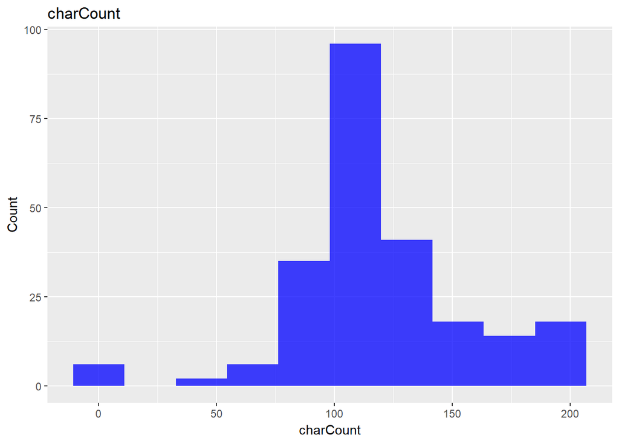

```r
#use the helper function provided
plotCharLengthDistribution(names(all))
```

The distribution of variable lengths is mostly > 100. Thankfully we are provided a file with shortened names. However these names might lose certain information and therefore we need to have all available information for later when we create new features.

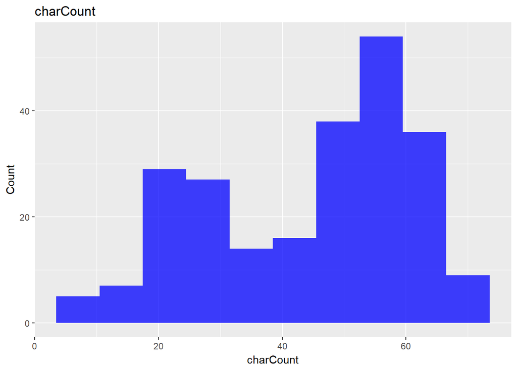

```r
#this df contains the information for the variable names and is helpful for understanding variable characteristics
Vnames_df<- fread("features-schema-descriptions.csv")

plotCharLengthDistribution(Vnames_df$short_name)
```

```r
#add 1 to the column since I added the filename
Vnames_df$column <- Vnames_df$column + 1

#a quick look at the column names of this df
names(Vnames_df)
```

```
## [1] "column"      "name"        "short_name"  "type"        "Description"
## [6] "Derived?"
```

```r
#assign shortened names to all
names(all)[-1] <- Vnames_df$short_name

#clean names of unwanted charachters
names(all)<- cleanNames(names(all))
```

```r
#there is a problem with the names and graphing isn't likeing the format so..
#save the actual colnames
short_names<- names(all)

#assign numeric values to the metric columns for graphing
names(all)[6:ncol(all)]<- 6:ncol(all)
```

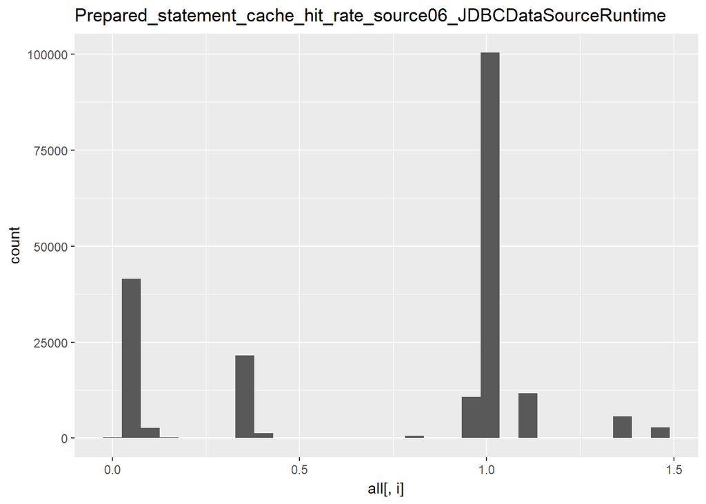

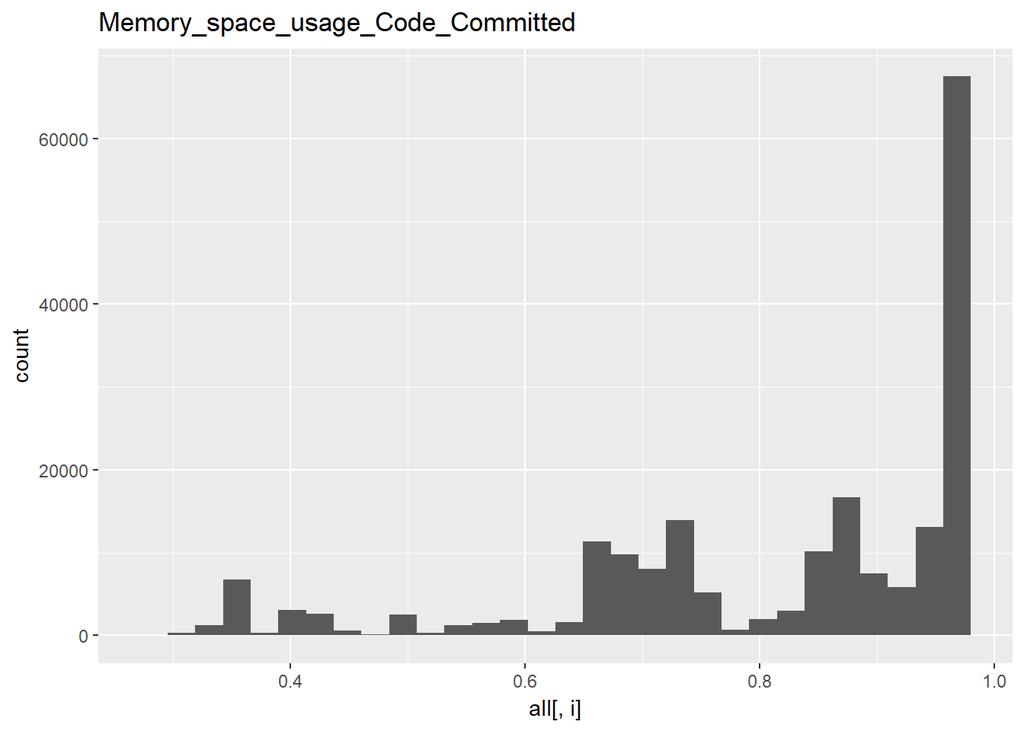

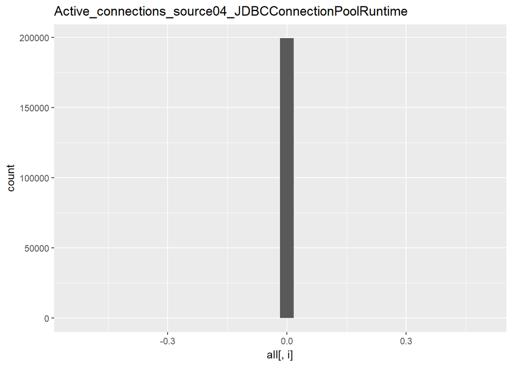

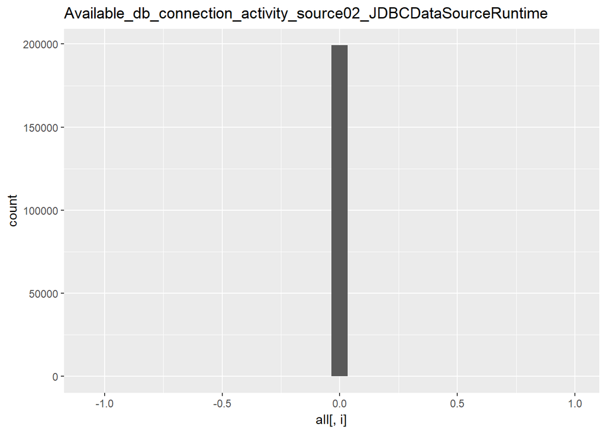

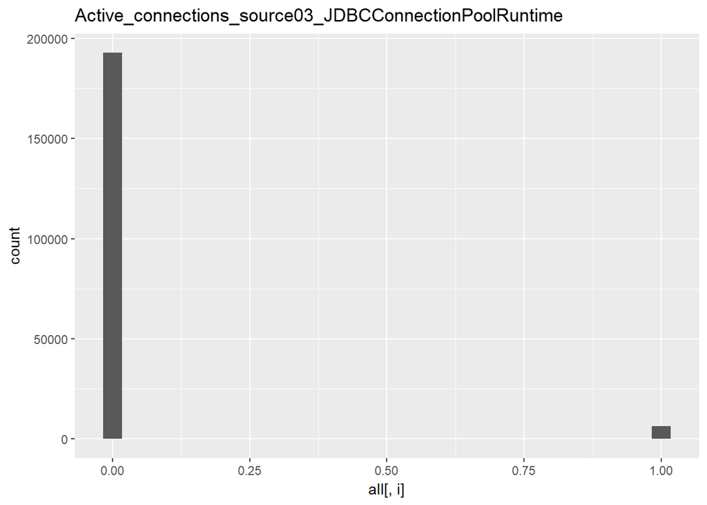

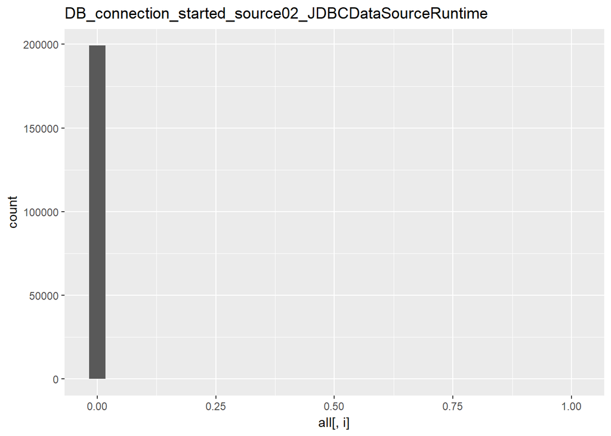

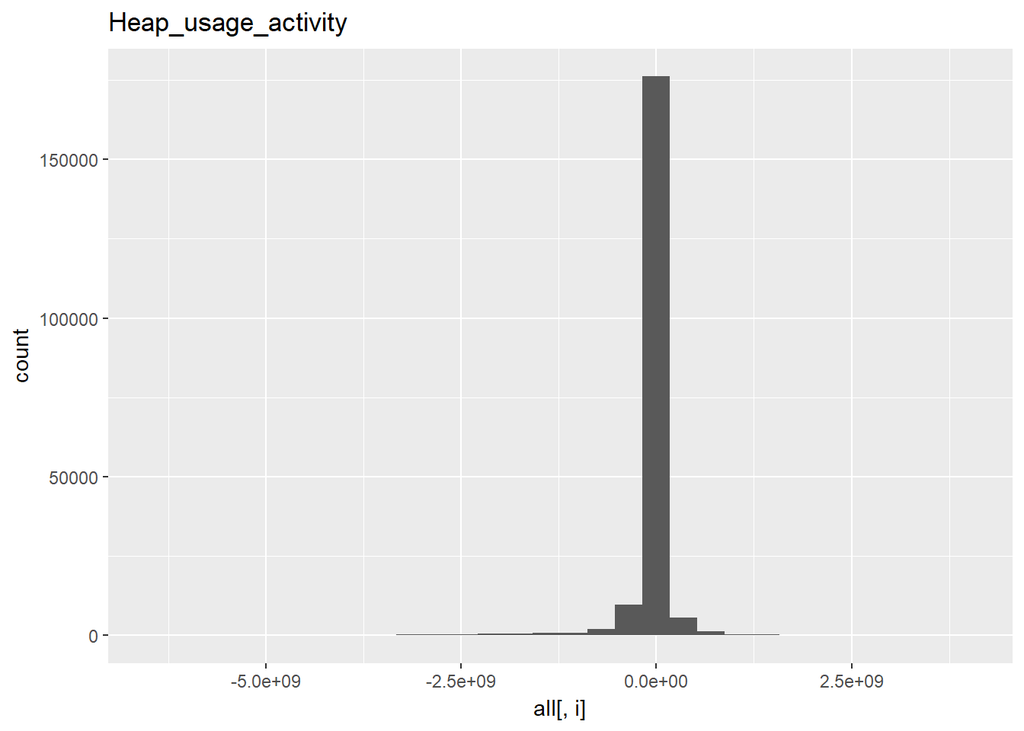

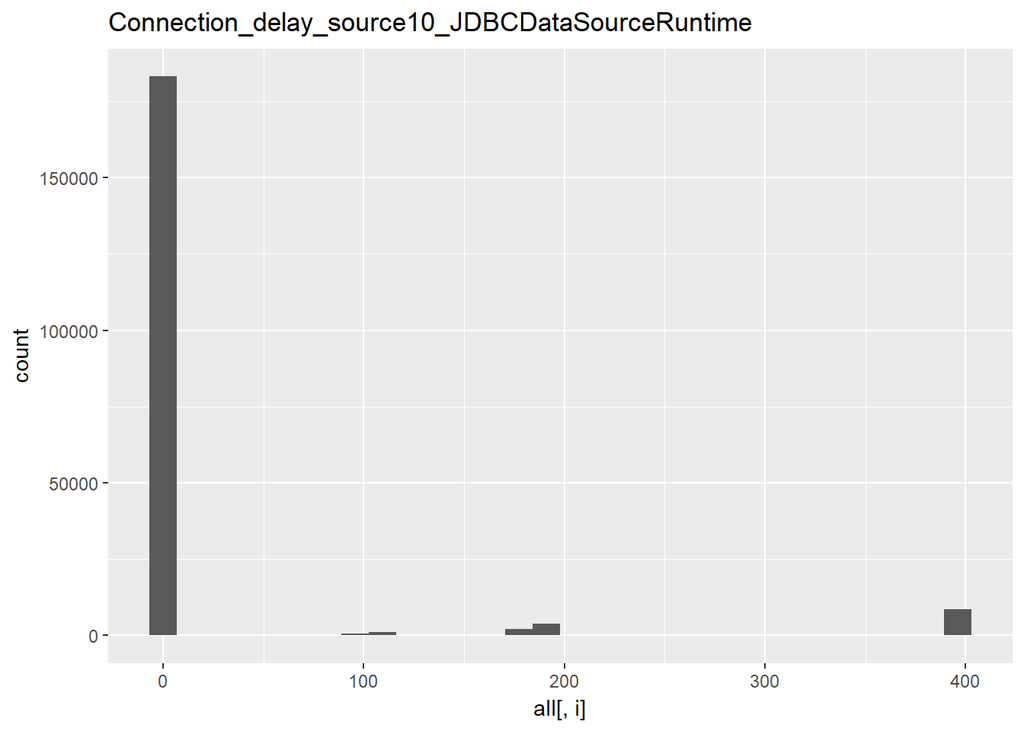

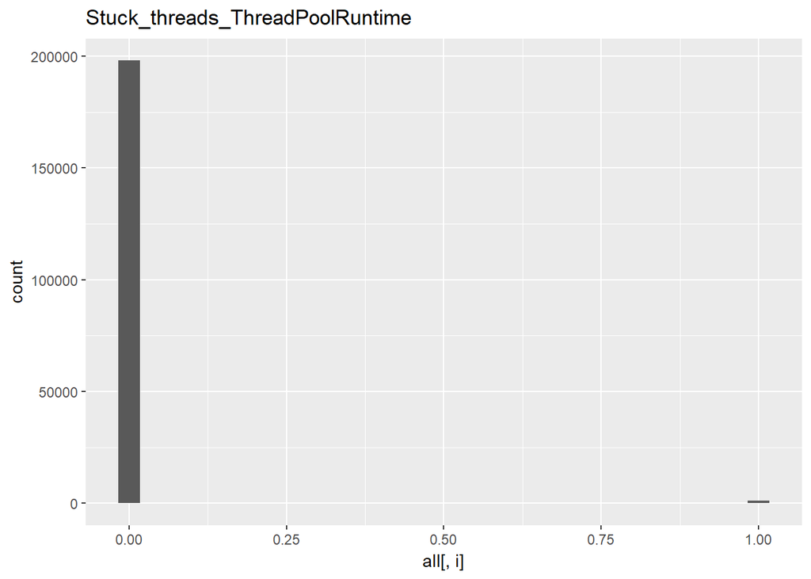

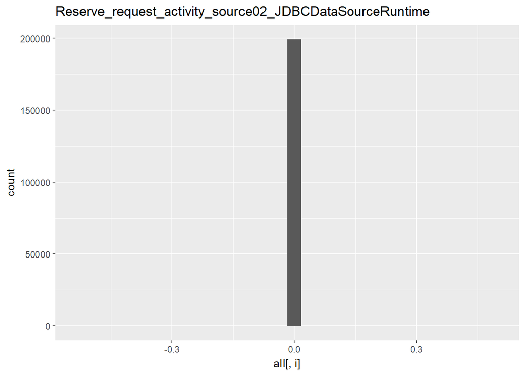

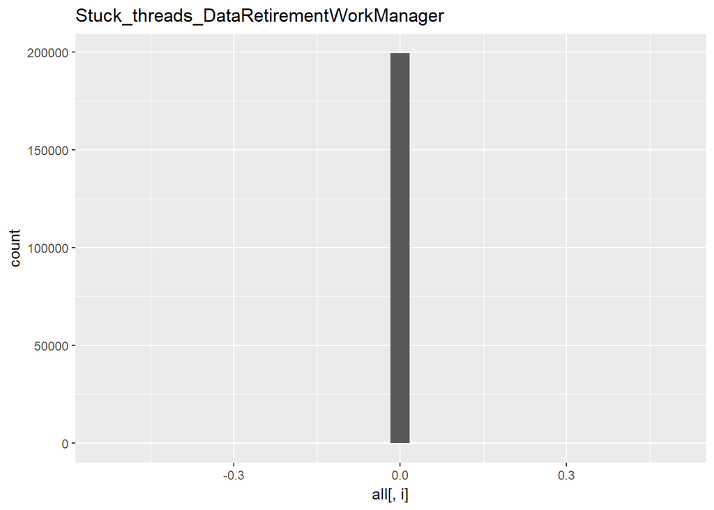

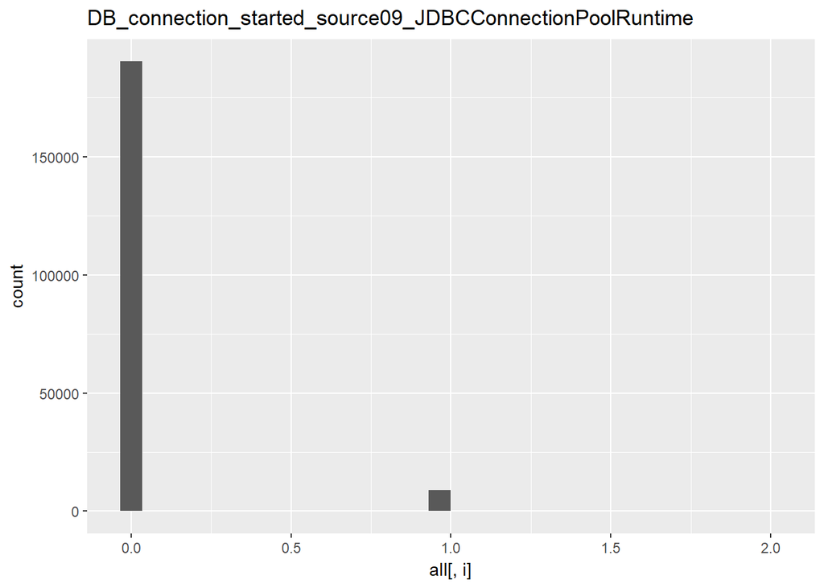

[9 more figures not shown]

```r
#look at some variable distributions to identify patters in different variables
for (i in 6:26) {
  print(qplot(x=all[,i], main = short_names[i]))
}
```

#### Removing Constant Variables

There are many variables that appear to be constants. These can be helpfull in the long run to identify anomalies however they wont be helpful to create new features. Therefore, I will need to identify them and remove them. The column names to be removed must be saved and chacked later when I look at a larger sample of all the data to determine if they truely are constants.

```r
#how many logical variables are there taht wont have normal summary stats
var_logicals<-vector("logical", ncol(all))
for (i in 1:ncol(all)){
  var_logicals[i]<- is.logical(all[,i])
}
sum(var_logicals)
```

```
## [1] 0
```

```r
names(all)[var_logicals]
```

```
## character(0)
```

```r
unique(all[,5])
```

```
## # A tibble: 1 x 1
##   isAnomaly
##   <lgl>
## 1 FALSE
```

“is.Anomaly” is FALSE for all observations, it is constant, and can be removed with all other identified constant variables.

```r
#remove constant variables
sum_var<- as.data.frame(matrix(NA, nrow=ncol(all), ncol = 6))
names(sum_var)<- c("Min.", "1st Qu.","Median", "Mean","3rd Qu.", "Max.")

for (i in 6:ncol(all)){
    sum_var[i,] <- as.numeric(str_split_fixed(summary(all[,i]), pattern = fixed(":"), 2)[,2])
}

#create index for constants
constants_index<- which(sum_var$Min. == sum_var$Max.)

#add "is.Anomaly"
constants_index<- c(5,constants_index)

#before subset add back column names
names(all)<- short_names

#subset for variable that are not constant
all_reduced<- all[,-constants_index]

Vnames_df_reduced<- Vnames_df[-(constants_index-1),]
```

Now lets look a some distributions again

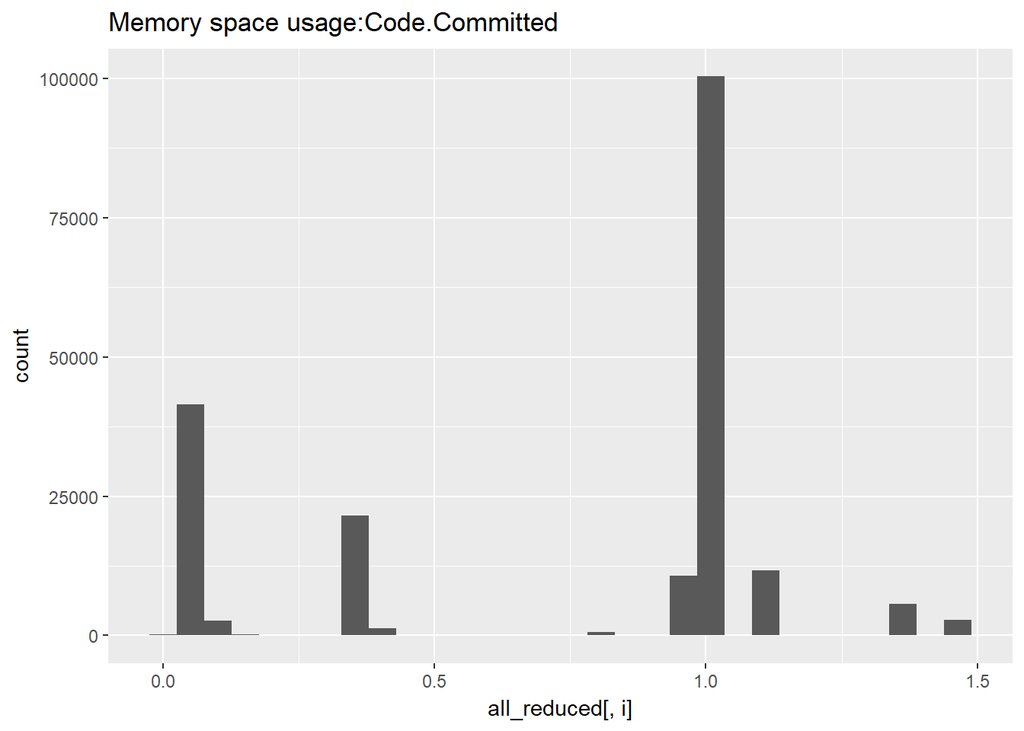

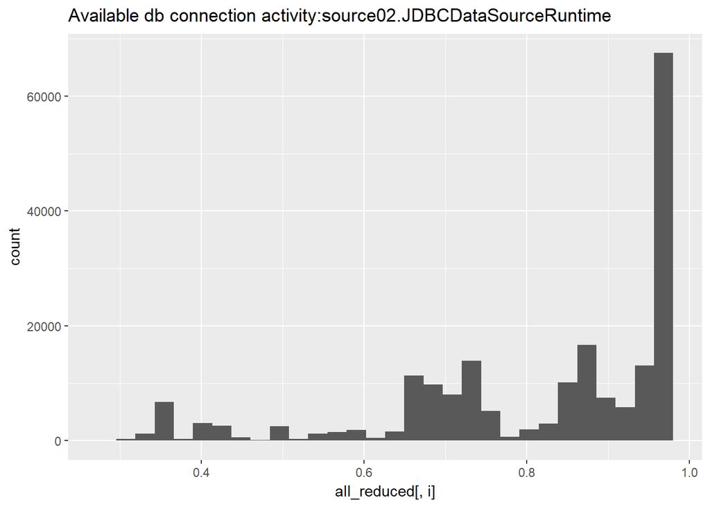

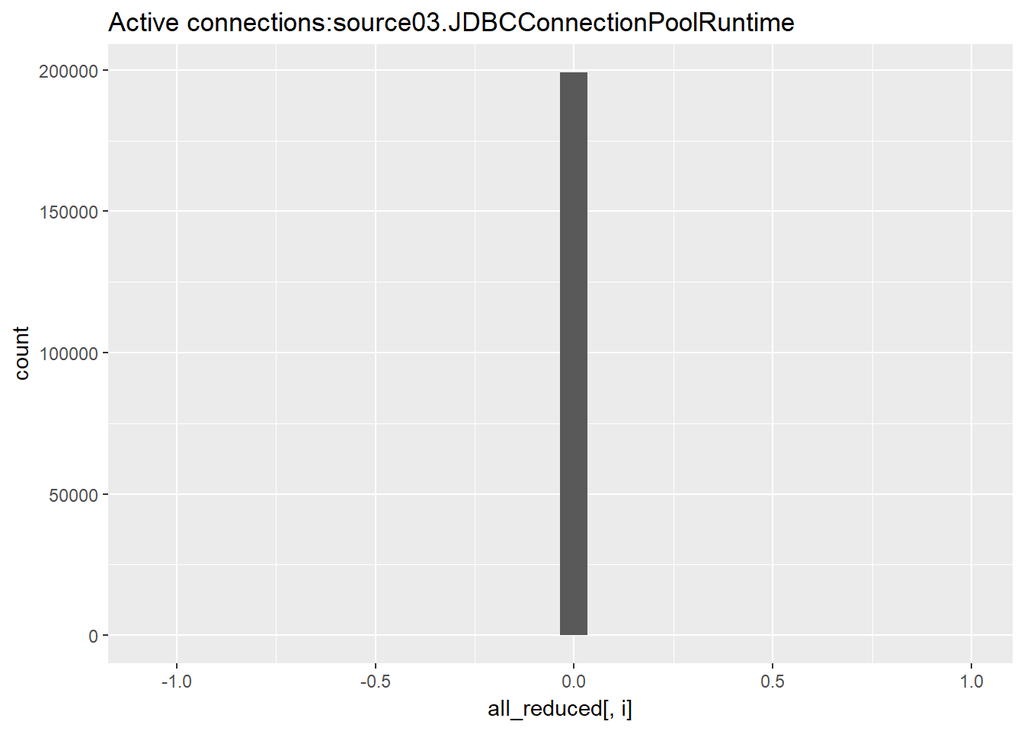

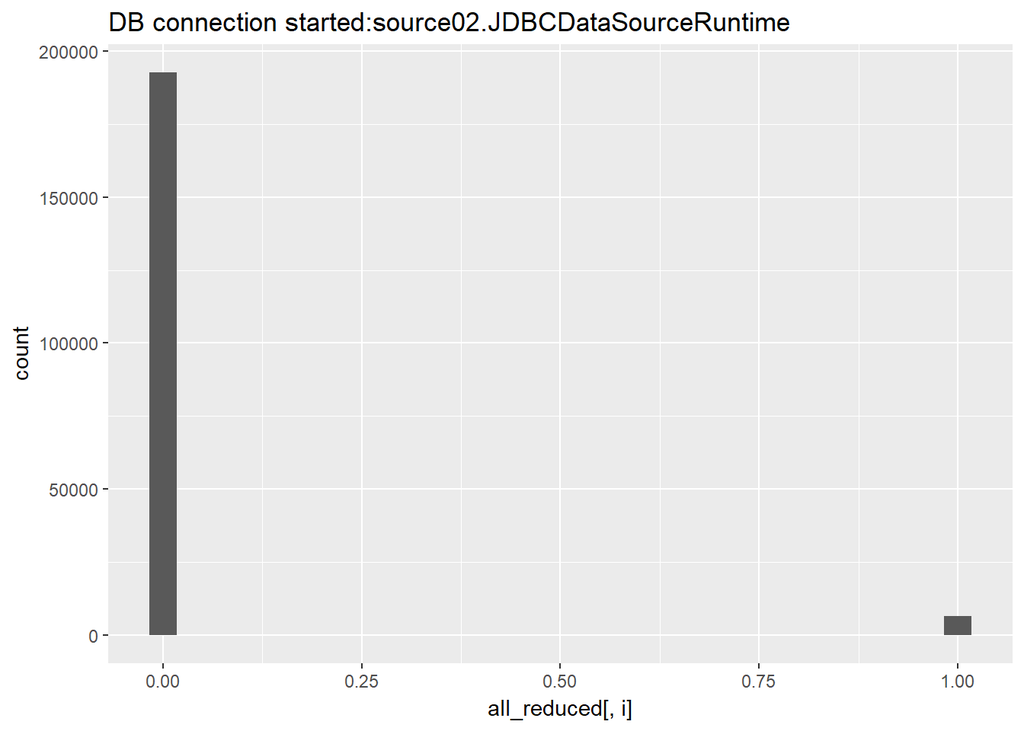

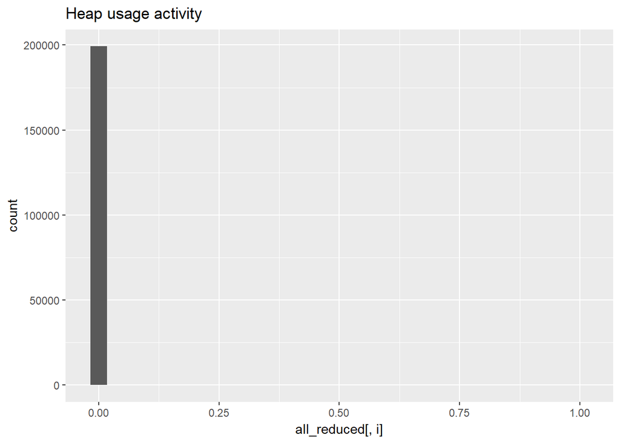

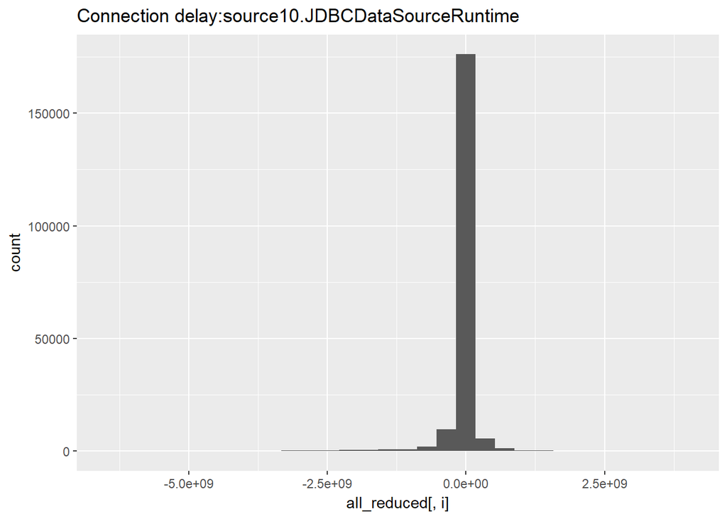

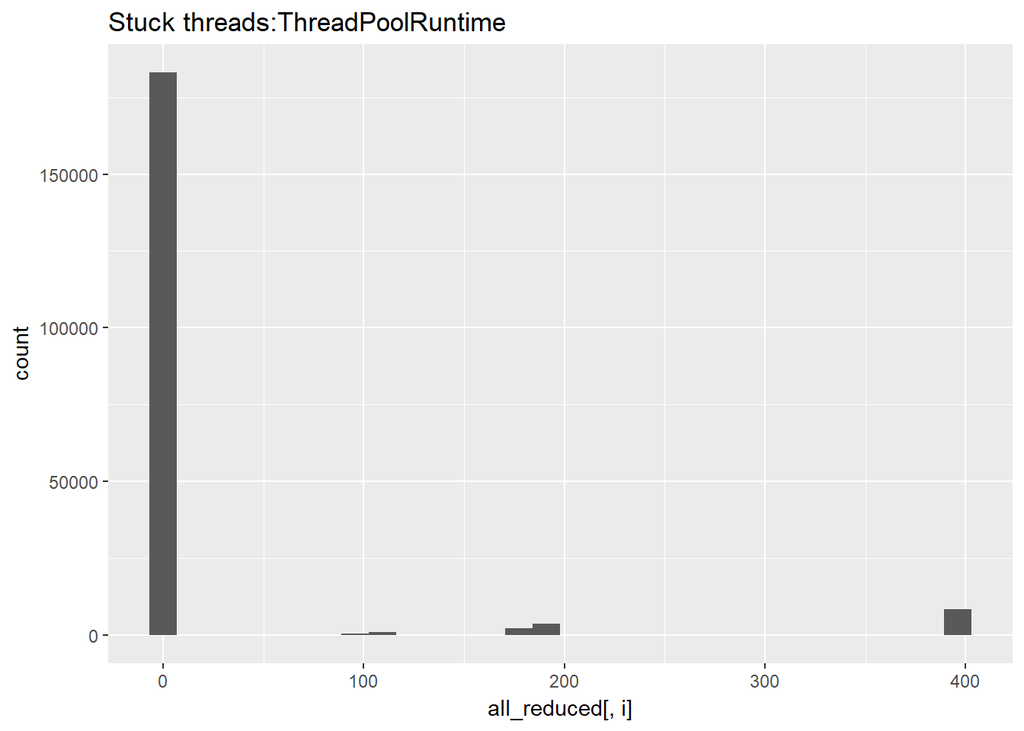

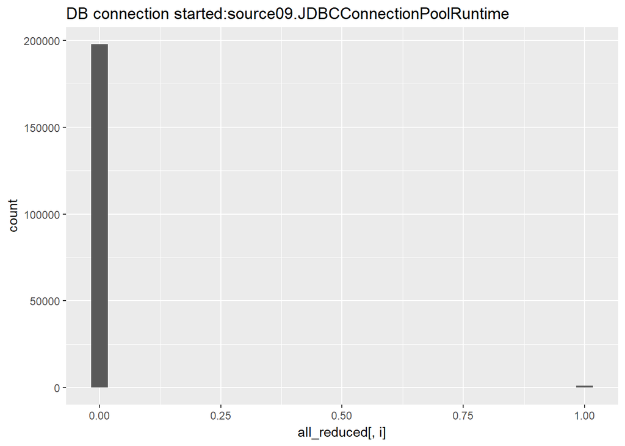

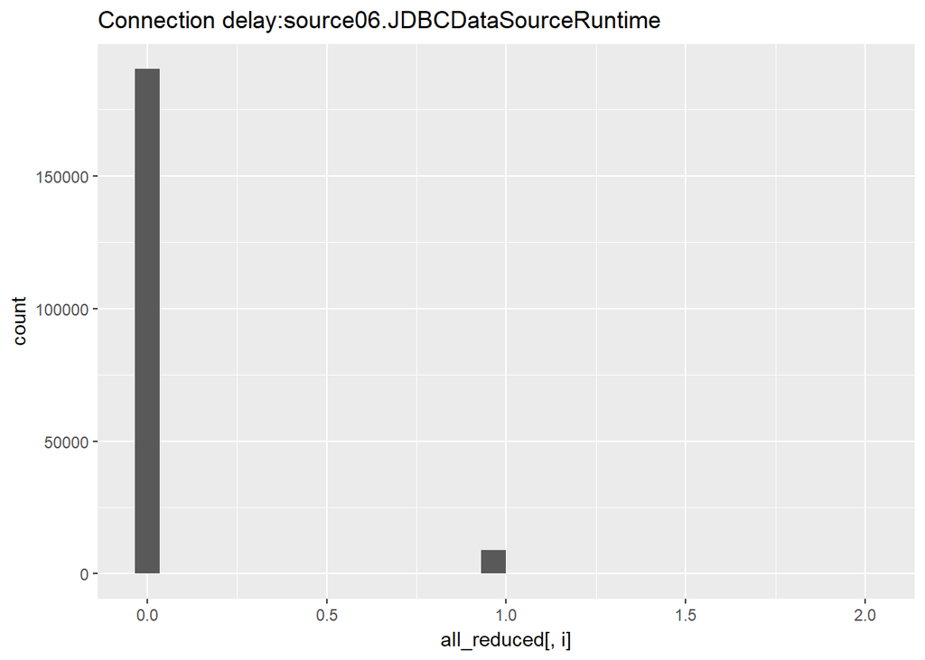

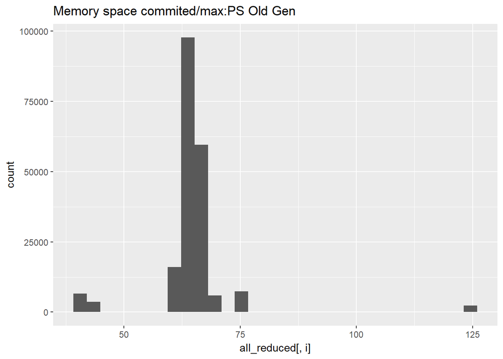

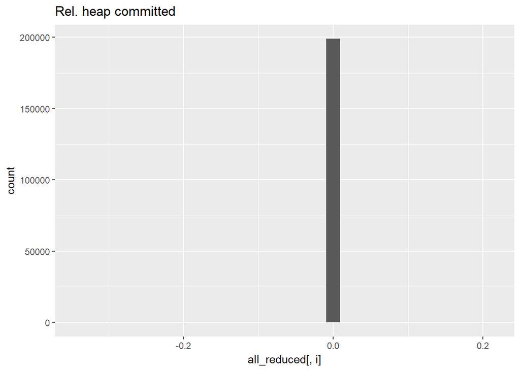

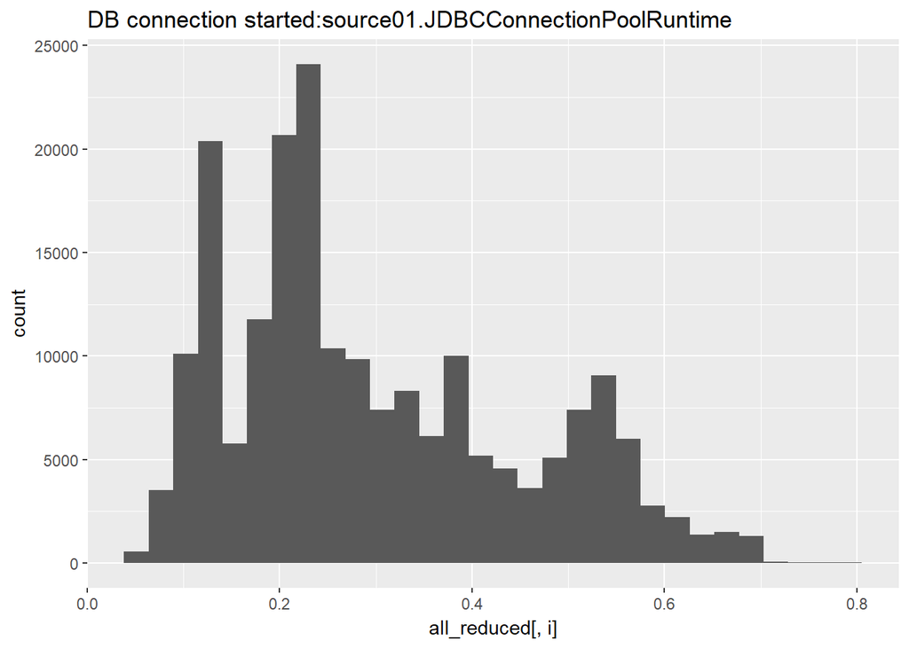

[4 more figures not shown]

```r
for ( i in 5:20) {
  print( qplot(x=all_reduced[,i], main = Vnames_df_reduced$short_name[i]))
}
```

Many variables are still mostly one value. Lets look at a few variables and the unique values. If there is a binary variable then the Min. = 0 and Max. = 1. These binary variables will be usefull in identifying anomalies later, however my goal is to create features by combining certain ones and reducing overall variable counts while making more meaningful features. Therefore I will remove these binary variables for now.This will make it easier to visually process the amount of data make scanning variabels easier.

```r
#find binary variables
sum_var_reduced <- sum_var[-constants_index,]

binary_index <- which(sum_var_reduced$Min.== 0 & sum_var_reduced$Max.==1)

all_reduced<- all_reduced[,-binary_index]

Vnames_df_reduced <- Vnames_df_reduced[-binary_index,]

ncol(all_reduced)
```

```
## [1] 97
```